# DETECTR 051 SpectraMax DETECTR and NANCI UMP Data

## UMP NEBuffer 4 + 2.1 Fresh Standard Curves for concentrations from 0.01uM to 10uM, including 0uM

- 0hr and 1hr single time points are first two plots
- Summation of all data points below 1hr and 11hr are the last two plots

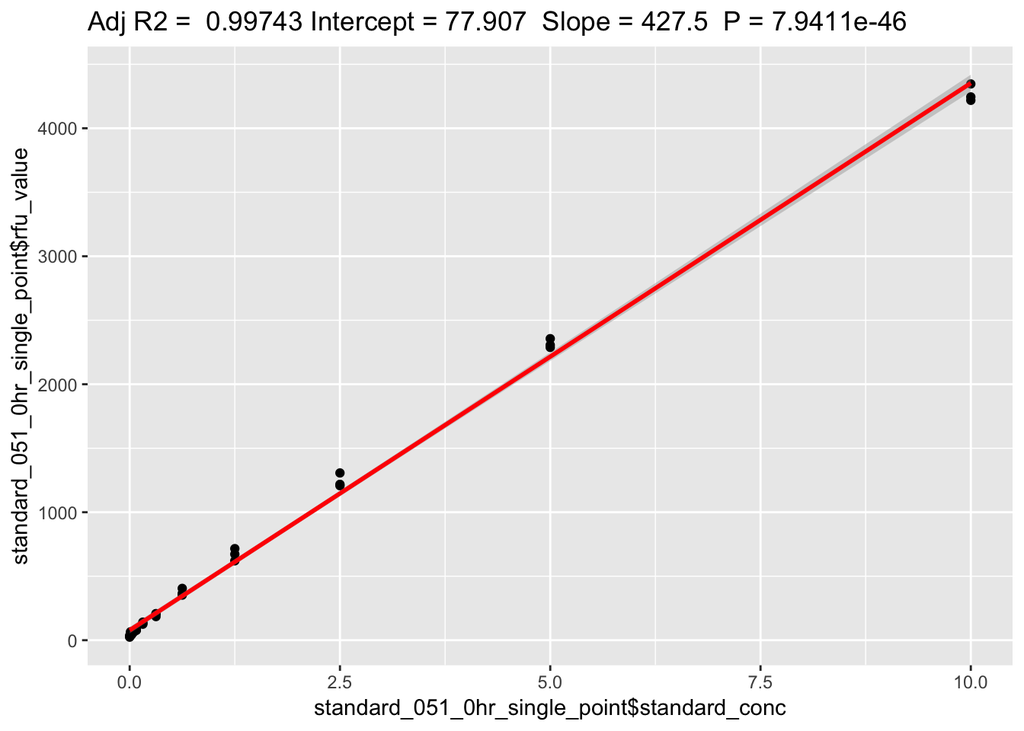

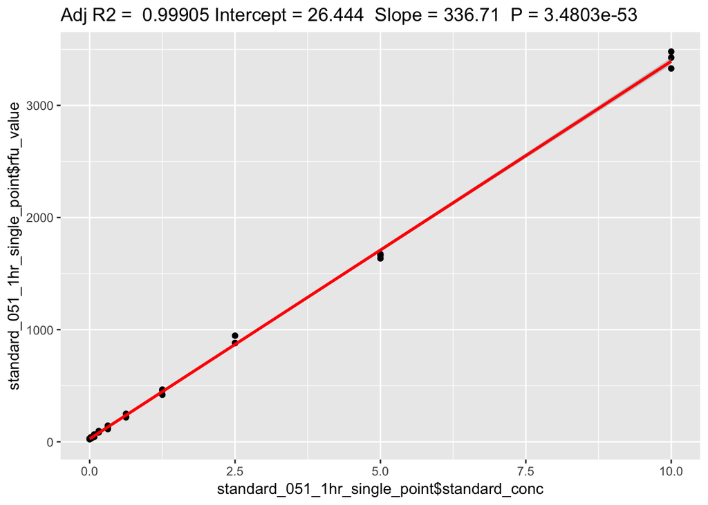

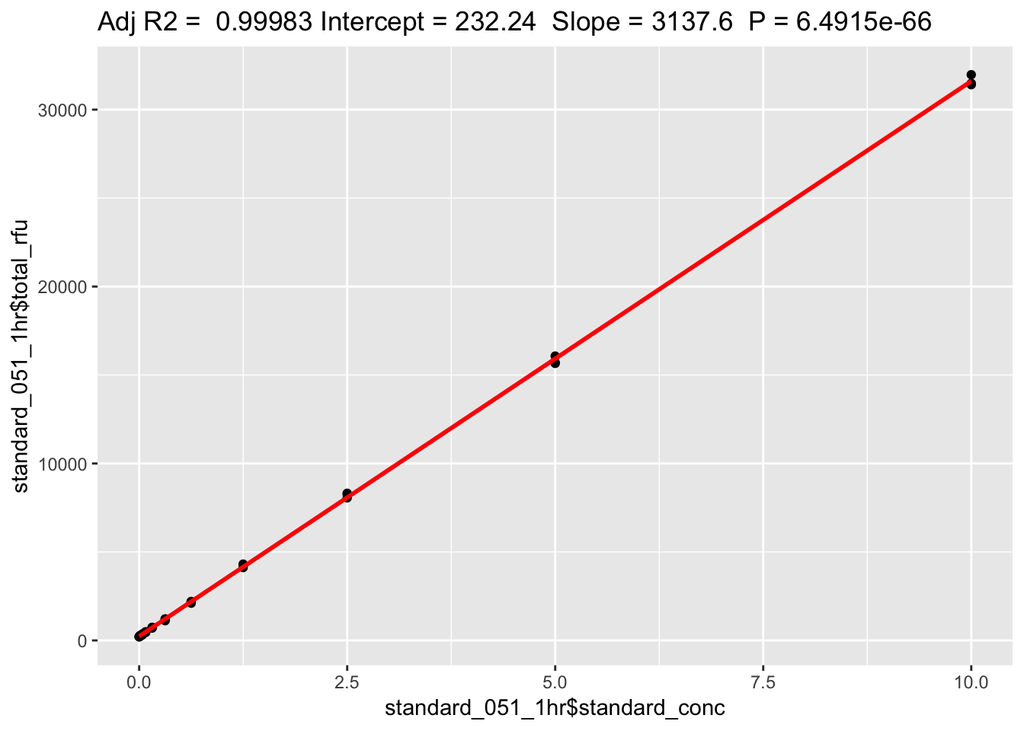

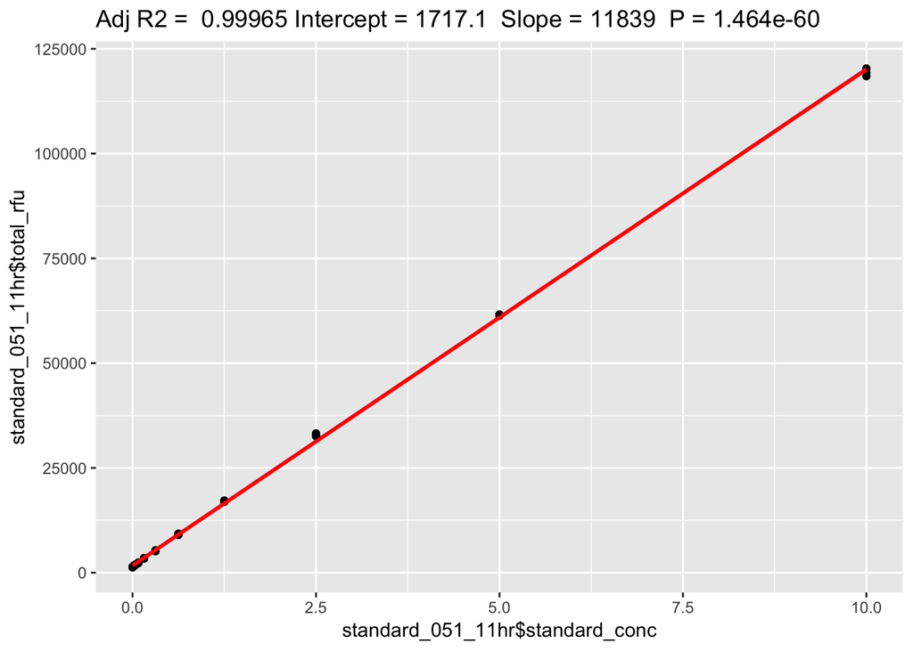

## UMP NEBuffer 4+ 2.1 Fresh Standard Curves for concentrations from 0.01uM to 0.16uM, including 0uM

- 0hr and 1hr single time points are first two plots
- Summation of all data points below 1hr and 11hr are the last two plots

### Conclusion

Same as before - summing reduces noise quite a bit. Can detect down to 0.02 uM with summing of just 1hr.

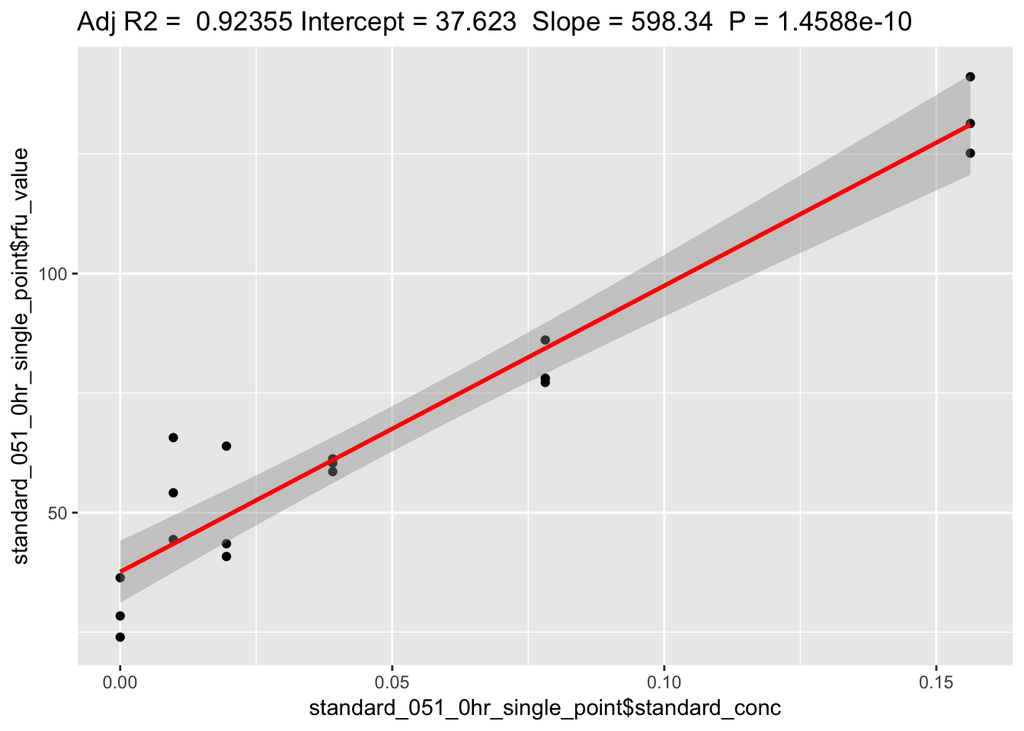

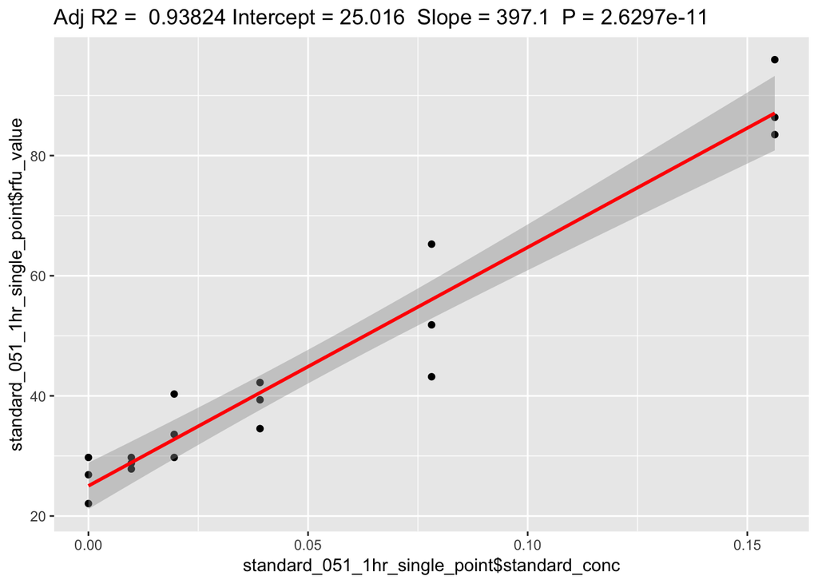

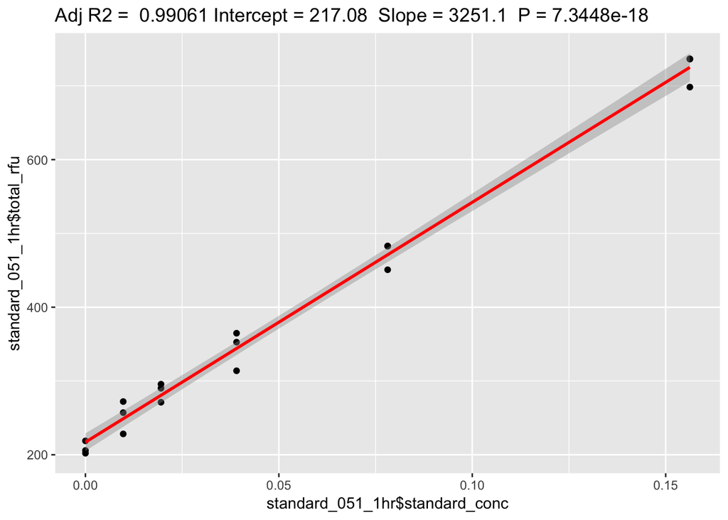

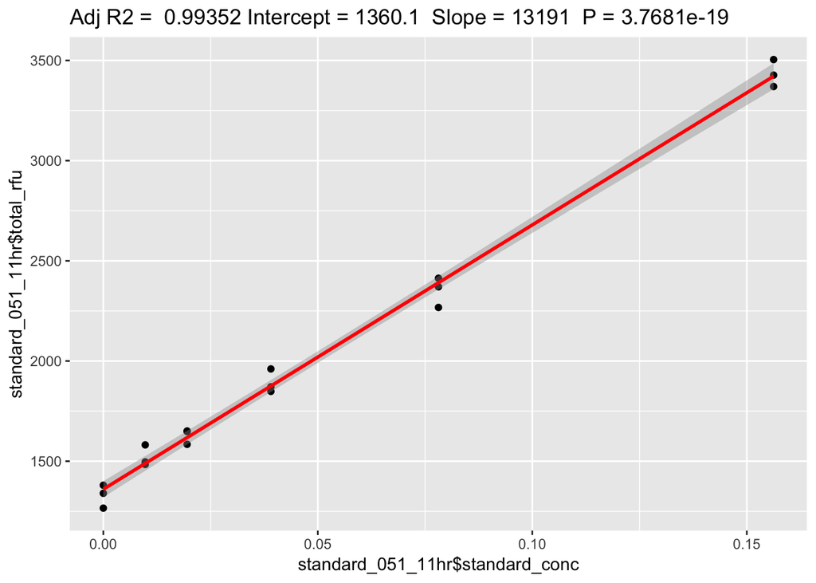

## NANCI UMP

- Used IDT cas12a and alt-R synthetic IS1081 gRNA with synthetic targets for all
- The reporter was r17U-TTATT-phos
- RFU values were converted to UMP uM concentrations using the 1hr summation regression
- Mismatched target is for IS6110

```
##
##  Welch Two Sample t-test
##
## data:  subset(samples_051_UMP, target_DNA_input_molecules %in% c(0, 2.4e+07))$total_rfu by subset(samples_051_UMP, target_DNA_input_molecules %in% c(0, 2.4e+07))$target_DNA_input_molecules
## t = -3.5929, df = 2.2685, p-value = 0.05748
## alternative hypothesis: true difference in means is not equal to 0
## 95 percent confidence interval:
##  -473.58134   16.33201
## sample estimates:
##       mean in group 0 mean in group 2.4e+07
##               955.099              1183.724
```

```
##
##  Welch Two Sample t-test
##
## data:  subset(samples_051_UMP, target_DNA_input_molecules %in% c(0, 2.4e+08))$total_rfu by subset(samples_051_UMP, target_DNA_input_molecules %in% c(0, 2.4e+08))$target_DNA_input_molecules
## t = -21.95, df = 2.0134, p-value = 0.002003
## alternative hypothesis: true difference in means is not equal to 0
## 95 percent confidence interval:
##  -7260.217 -4893.077
## sample estimates:
##       mean in group 0 mean in group 2.4e+08
##               955.099              7031.746
```

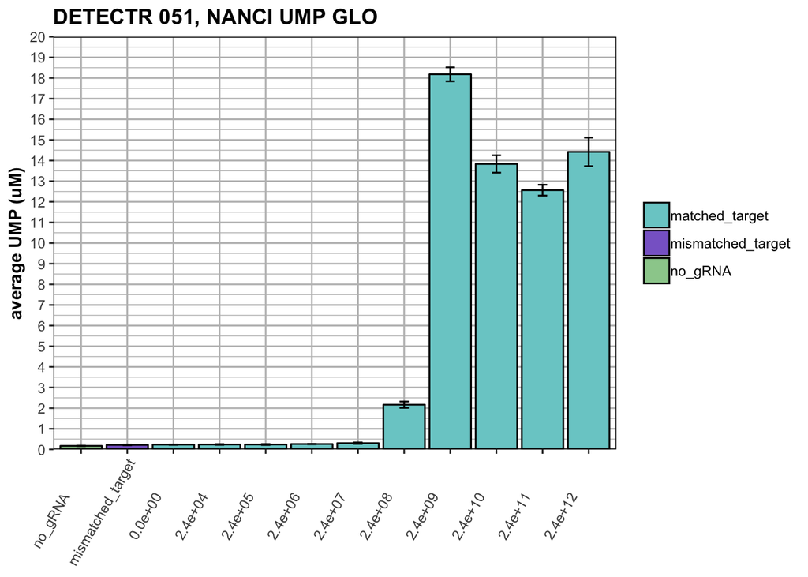

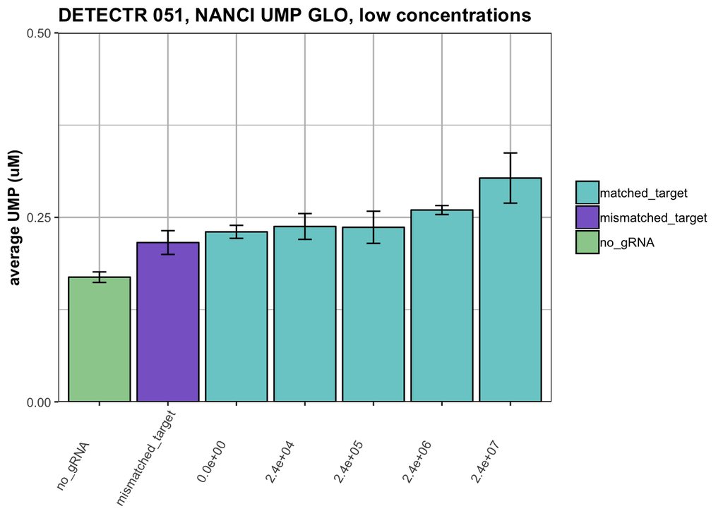

## DETECTR

- Used IDT cas12a and alt-R synthetic IS1081 gRNA with synthetic targets for all
- The reporter was FAM-TTATT-IowaBlk
- RFU values were a sum of all points up to 1hr
- Background is reporter MM + water (no cas12a, gRNA, etc)
- Mismatched target is for IS6110

```
##
##  Welch Two Sample t-test
##
## data:  subset(samples_051, target_DNA_input_molecules %in% c(0, 2.4e+07))$total_rfu by subset(samples_051, target_DNA_input_molecules %in% c(0, 2.4e+07))$target_DNA_input_molecules
## t = -1.749, df = 3.9832, p-value = 0.1555
## alternative hypothesis: true difference in means is not equal to 0
## 95 percent confidence interval:
##  -2.7756818  0.6323485
## sample estimates:
##       mean in group 0 mean in group 2.4e+07
##              14.83500              15.90667
```

```
##
##  Welch Two Sample t-test
##
## data:  subset(samples_051, target_DNA_input_molecules %in% c(0, 2.4e+08))$total_rfu by subset(samples_051, target_DNA_input_molecules %in% c(0, 2.4e+08))$target_DNA_input_molecules
## t = -38.539, df = 2.072, p-value = 0.0005425
## alternative hypothesis: true difference in means is not equal to 0
## 95 percent confidence interval:
##  -143.5860 -115.5926
## sample estimates:
##       mean in group 0 mean in group 2.4e+08
##               14.8350              144.4243
```

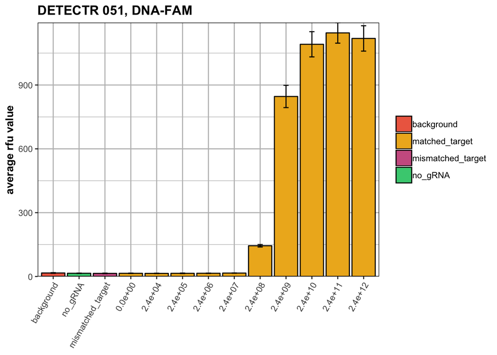

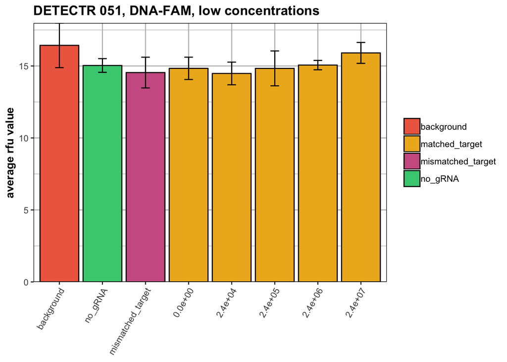

## Kinetics

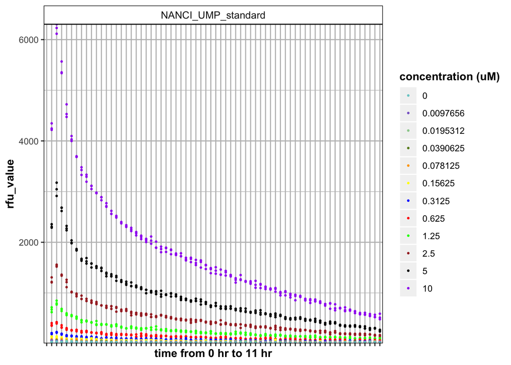

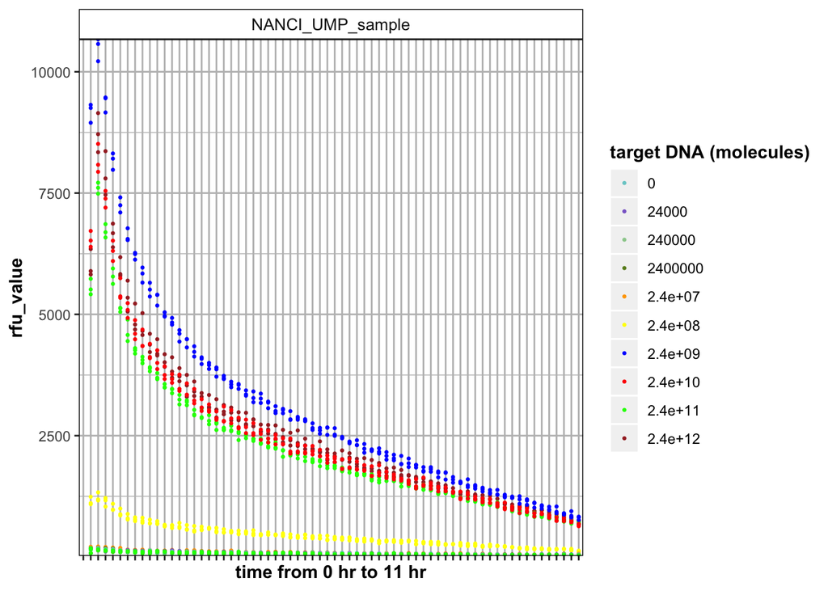

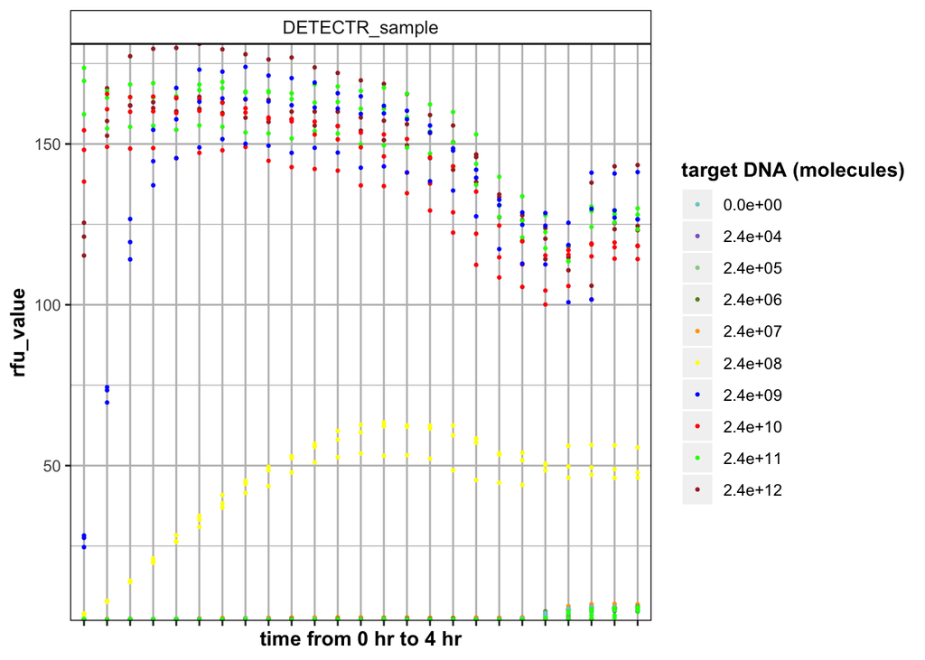